# Notebook 05 – Solutions

DSST289: Introduction to Data Science

Author

Erik Fredner

Published

September 8, 2024

## Getting Started

Before running this notebook, select “Session > Restart R and Clear Output” in the menu above to start a new R session. This will clear any old data sets and give us a blank slate to start with.

After starting a new session, run the following code chunk to load the libraries and data that we will be working with today.

I have set the options `include=FALSE` and `message=FALSE` to avoid cluttering the solutions with all the output from this code.

# Data

We will work with the largest cities data sets:

```r
cities <- read_csv("../data/largest_cities.csv")
cities
```

| name | country | city_definition | population | city_pop | city_area | metro_pop | metro_area | urban_pop | urban_area | wiki | country_code2 | country_code3 | country_name_official | continent | lon | lat | koppen_code | koppen_main | city | num | cost_of_living | cost_rent | cost_groceries | cost_restaurant | local_pp |
| --- | --- | --- | --- | --- | --- | --- | --- | --- | --- | --- | --- | --- | --- | --- | --- | --- | --- | --- | --- | --- | --- | --- | --- | --- | --- |
| Tokyo | Japan | Metropolis prefecture | 37.400 | 13.515 | 2191.00 | 37.274 | 13452.0 | 38.505 | 8223 | Tokyo | JP | JPN | Japan | Asia | 139.692222 | 35.689722 | Cfa | Temperate | Tokyo, Japan | 18 | 86.87 | 38.00 | 83.42 | 56.70 | 89.70 |
| Delhi | India | National capital territory | 28.514 | 16.753 | 1484.00 | 29.000 | 3483.0 | 28.125 | 2240 | Delhi | IN | IND | India, Republic of | Asia | 77.230000 | 28.610000 | BSh | Dry | Delhi, India | 405 | 28.18 | 8.18 | 26.15 | 24.76 | 54.69 |
| Shanghai | China | Municipality | 25.582 | 24.183 | 6341.00 | NA | NA | 22.125 | 4015 | Shanghai | CN | CHN | China, People's Republic of | Asia | 121.474722 | 31.228611 | Cfa | Temperate | Shanghai, China | 235 | 50.07 | 35.67 | 52.50 | 36.48 | 54.40 |
| São Paulo | Brazil | Municipality | 21.650 | 12.252 | 1521.00 | 21.735 | 7947.0 | 20.935 | 3043 | Sao_Paulo | BR | BRA | Brazil, Federative Republic of | South America | -46.633333 | -23.550000 | Cfb | Temperate | Sao Paulo, Brazil | 257 | 45.52 | 16.28 | 33.29 | 39.70 | 31.97 |
| Mexico City | Mexico | City-state | 21.581 | 8.919 | 1485.00 | 20.893 | 7854.0 | 20.395 | 237 | Mexico_City | MX | MEX | Mexico, United Mexican States | North America | -99.133333 | 19.433333 | Cwb | Temperate | Mexico City, Mexico | 317 | 38.55 | 20.43 | 33.75 | 33.11 | 42.91 |
| Cairo | Egypt | Urban governorate | 20.076 | 9.500 | 3085.00 | NA | NA | 16.925 | 1917 | Cairo | EG | EGY | Egypt, Arab Republic of | Africa | 31.228889 | 30.058056 | BWh | Dry | Cairo, Egypt | 393 | 30.94 | 6.48 | 26.41 | 25.43 | 24.53 |
| Mumbai | India | Municipality | 19.980 | 12.478 | 603.00 | 24.400 | 4355.0 | 23.645 | 881 | Mumbai | IN | IND | India, Republic of | Asia | 72.825833 | 18.975000 | Am | Tropical | Mumbai, India | 399 | 28.84 | 21.02 | 26.86 | 26.61 | 41.68 |
| Beijing | China | Municipality | 19.618 | 21.707 | 16411.00 | NA | NA | 19.430 | 4144 | Beijing | CN | CHN | China, People's Republic of | Asia | 116.383333 | 39.916667 | Cwa | Temperate | Beijing, China | 261 | 44.89 | 34.97 | 43.08 | 35.85 | 60.72 |
| Dhaka | Bangladesh | Capital city | 19.578 | 14.399 | 338.00 | 14.543 | NA | 18.595 | 453 | Dhaka | BD | BGD | Bangladesh, People's Republic of | Asia | 90.388889 | 23.763889 | Aw | Tropical | Dhaka, Bangladesh | 370 | 34.52 | 5.69 | 31.58 | 20.02 | 33.45 |
| Osaka | Japan | Designated city | 19.281 | 2.725 | 225.00 | 19.303 | 13228.0 | 17.150 | 3004 | Osaka | JP | JPN | Japan | Asia | 135.502222 | 34.693889 | Cfa | Temperate | Osaka, Japan | 33 | 79.54 | 22.63 | 77.66 | 45.48 | 85.82 |

[output cut: 71 more lines]

We will now also work with the entire U.S. cities data set:

```r
us <- read_csv("../data/us_city_population.csv") |>
  filter(!is.na(population))
us
```

| city | state | year | population | lon | lat |
| --- | --- | --- | --- | --- | --- |
| Anchorage, AK | AK | 1790 | 0.000 | -149.27435 | 61.17755 |
| Birmingham, AL | AL | 1790 | 0.000 | -86.79905 | 33.52744 |
| Huntsville, AL | AL | 1790 | 0.000 | -86.53900 | 34.78427 |
| Mobile, AL | AL | 1790 | 0.000 | -88.10023 | 30.66843 |
| Montgomery, AL | AL | 1790 | 0.000 | -86.26859 | 32.34625 |
| Little Rock, AR | AR | 1790 | 0.000 | -92.35856 | 34.72543 |
| Chandler, AZ | AZ | 1790 | 0.000 | -111.85494 | 33.28287 |
| Gilbert, AZ | AZ | 1790 | 0.000 | -111.74219 | 33.31021 |
| Glendale, AZ | AZ | 1790 | 0.000 | -112.18990 | 33.53311 |
| Mesa, AZ | AZ | 1790 | 0.000 | -111.71738 | 33.40193 |

[output cut: 6681 more lines]

Please refer to the previous notebooks for more information about these data sets and how these data sets are organized.

# Practice

## Summary Statistics

In the code block below, using the `summarize` function to compute the mean population (`population`) in the `cities` dataset.

```r
cities |>
  summarize(city_pop_mean = mean(population))
```

| city_pop_mean |
| --- |
| 10.54277 |

## Grouped Summaries

Let’s now try to use grouped summarize functions. There is a feature in the `cities` data set called `city_definition`. It describes the kind of administrative structure given to each city. Using a grouped summary, in the code below tabulate how many times each city definition is used in the dataset. Arrange the data in decreasing order from the most common to least common definition.

```r
cities |>
  group_by(city_definition) |>
  summarize(num_rows = n()) |>
  arrange(desc(num_rows))
```

| city_definition | num_rows |
| --- | --- |
| Municipality | 20 |
| City (sub-provincial) | 14 |
| City | 8 |
| Other | 6 |
| Capital city | 3 |
| Designated city | 3 |
| Metropolitan municipality | 3 |
| Urban governorate | 3 |
| Federal city | 2 |
| Metropolitan city | 2 |

[output cut: 17 more lines]

What city type is the most common in the dataset? **Answer**: Municipality.

Now, count and arrange in descending order the feature `koppen_code`.

```r
cities |>
  group_by(koppen_code) |>
  summarize(n = n()) |>
  arrange(desc(n))
```

| koppen_code | n |
| --- | --- |
| Cfa | 20 |
| Aw | 11 |
| Cwa | 7 |
| BSh | 6 |
| BWh | 6 |
| Cfb | 5 |
| Am | 4 |
| BSk | 4 |
| Dwa | 4 |
| Af | 3 |

[output cut: 6 more lines]

What Köppen Code is the most common in the dataset? **Answer**: Cfa.

Now, in the code below group by continent and paste together the city names (`name`).

```r
cities |>
  group_by(continent) |>
  summarize(names = paste(name, collapse = "|")) |>
  # passing to `print` to make the solutions easy to read;
  # you don't need this in your code:
  print()
```

```
# A tibble: 5 × 2
  continent     names
  <chr>         <chr>
1 Africa        Cairo|Lagos|Kinshasa|Luanda|Dar es Salaam|Khartoum|Johannes…
2 Asia          Tokyo|Delhi|Shanghai|Mumbai|Beijing|Dhaka|Osaka|Karachi|Cho…
3 Europe        Istanbul|Moscow|Paris|London|Madrid|Barcelona|Saint Petersb…
4 North America Mexico City|New York City|Los Angeles|Chicago|Houston|Dalla…
5 South America São Paulo|Buenos Aires|Rio de Janeiro|Bogotá|Lima|Santiago|…
```

You will probably have to scroll over to see the results.

Finally, in the code below group by continent, count the number of cities in each continent, and pass this to a plot with a `geom_col` layer to visualize the number of cities on each continent.

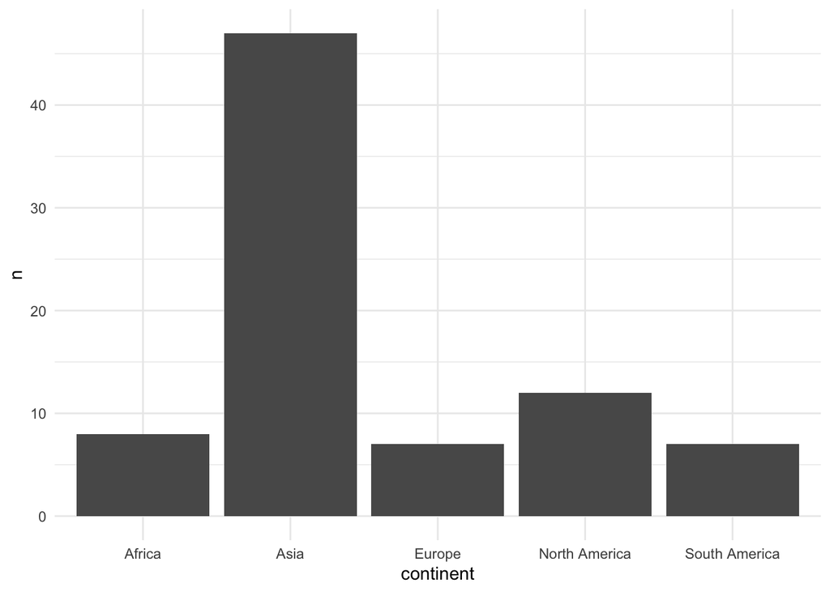

```r
cities |>
  group_by(continent) |>
  summarize(n = n()) |>
  ggplot(aes(continent, n)) +
  geom_col()
```

## Summarize Trends in U.S. Cities Data

We will now turn to the U.S. cities dataset to perform some more involved uses of the summary function. To start, group by the year feature and summarize the dataset by taking the sum of the population in every city for each year (with `sum`). Draw a plot with `geom_line` and `geom_point` to show the population trend in these 300 U.S. cities over time.

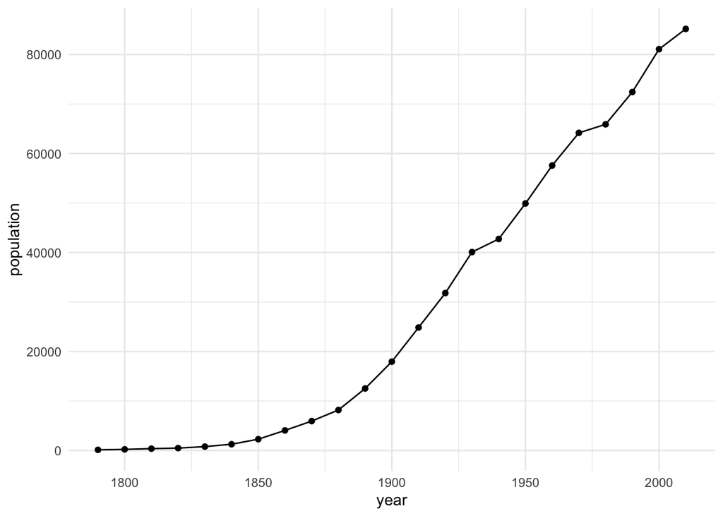

```r
us |>
  group_by(year) |>
  summarize(population = sum(population)) |>
  ggplot(aes(year, population)) +
  geom_line() +
  geom_point()
```

The population feature in this data set is given in thousands of people. In 2000 there were approximately 300 million people living in the United States. Roughly what fraction of people in the year 2000 appear to have lived in one of the largest 300 cities according to this plot? **Answer**: It looks like about 80 million live in these cities, so about 25%.

## Grouped Arrange and Slice

In the notes we used the `group_by` function to manipulate the summarize function. However, the functions `arrange`, `slice`, and `filter` also respect the grouping of a data set. This can be quite useful. For example, consider grouping the US cities data set by year, arrange in descending order by population, and then using `slice` to take the first five rows. This would result in a data set that gives the five largest cities for each year in our data set. Write the code to do this below and visually verify that it seems to pick out five cities for each year:

```r
us |>
  group_by(year) |>
  arrange(desc(population)) |>
  slice(1:5)
```

| city | state | year | population | lon | lat |
| --- | --- | --- | --- | --- | --- |
| New York City, NY | NY | 1790 | 33.131 | -73.93850 | 40.66427 |
| Philadelphia, PA | PA | 1790 | 28.522 | -75.13335 | 40.00938 |
| Boston, MA | MA | 1790 | 18.320 | -71.02017 | 42.33196 |
| Charleston, SC | SC | 1790 | 16.359 | -79.95893 | 32.81792 |
| Baltimore, MD | MD | 1790 | 13.503 | -76.61052 | 39.30021 |
| New York City, NY | NY | 1800 | 60.515 | -73.93850 | 40.66427 |
| Philadelphia, PA | PA | 1800 | 41.220 | -75.13335 | 40.00938 |
| Baltimore, MD | MD | 1800 | 26.514 | -76.61052 | 39.30021 |
| Boston, MA | MA | 1800 | 24.937 | -71.02017 | 42.33196 |
| Charleston, SC | SC | 1800 | 18.824 | -79.95893 | 32.81792 |

[output cut: 105 more lines]

Starting with the code in the previous block, summarize the data set by pasting together the city names.

```r
us |>
  group_by(year) |>
  arrange(desc(population)) |>
  slice(1:5) |>
  summarize(cities = paste(city, collapse = "|")) |>
  # again, just for ease of viewing in the solutions; `print` is not needed:
  print()
```

```
# A tibble: 23 × 2
    year cities
   <dbl> <chr>
 1  1790 New York City, NY|Philadelphia, PA|Boston, MA|Charleston, SC|Balti…
 2  1800 New York City, NY|Philadelphia, PA|Baltimore, MD|Boston, MA|Charle…
 3  1810 New York City, NY|Philadelphia, PA|Baltimore, MD|Boston, MA|Charle…
 4  1820 New York City, NY|Philadelphia, PA|Baltimore, MD|Boston, MA|New Or…
 5  1830 New York City, NY|Baltimore, MD|Philadelphia, PA|Boston, MA|New Or…
 6  1840 New York City, NY|Baltimore, MD|New Orleans, LA|Philadelphia, PA|B…
 7  1850 New York City, NY|Baltimore, MD|Boston, MA|Philadelphia, PA|New Or…
 8  1860 New York City, NY|Philadelphia, PA|Baltimore, MD|Boston, MA|New Or…
 9  1870 New York City, NY|Philadelphia, PA|St. Louis, MO|Chicago, IL|Balti…
10  1880 New York City, NY|Philadelphia, PA|Chicago, IL|Boston, MA|St. Loui…
# ℹ 13 more rows
```

In the code below, write the code to select one row for each city corresponding to the year that the city had its largest population. (Note: think about this carefully before you start writing the code).

```r
us |>
  group_by(city) |>
  arrange(desc(population)) |>
  slice(1)
```

| city | state | year | population | lon | lat |
| --- | --- | --- | --- | --- | --- |
| Abilene, TX | TX | 2010 | 117.063 | -99.73815 | 32.45451 |
| Akron, OH | OH | 1960 | 290.351 | -81.52143 | 41.08046 |
| Albany, NY | NY | 1950 | 134.995 | -73.79835 | 42.66575 |
| Albuquerque, NM | NM | 2010 | 545.852 | -106.64739 | 35.10555 |
| Alexandria, VA | VA | 2010 | 139.966 | -77.08203 | 38.81834 |
| Allentown, PA | PA | 2010 | 118.032 | -75.47816 | 40.59397 |
| Amarillo, TX | TX | 2010 | 190.695 | -101.82875 | 35.19784 |
| Anaheim, CA | CA | 2010 | 336.265 | -117.76007 | 33.85550 |
| Anchorage, AK | AK | 2010 | 291.826 | -149.27435 | 61.17755 |
| Ann Arbor, MI | MI | 2000 | 114.024 | -83.73133 | 42.27564 |

[output cut: 290 more lines]

It would be helpful to sort the dataset you created in the previous code block by the year feature. That would let us see the cities that peaked earliest at the top of the dataset. However, if we added an arrange function at the end of the code you wrote nothing would happen because dataset still grouped by city. We need to first ungroup the dataset with the `ungroup()` function. In the code below, starting with what you wrote in the block above, ungroup the dataset and arrange by year:

```r
us |>
  group_by(city) |>
  arrange(desc(population)) |>
  slice(1) |>
  arrange(year) |>
  ungroup() |>
  arrange(year)
```

| city | state | year | population | lon | lat |
| --- | --- | --- | --- | --- | --- |
| Fall River, MA | MA | 1920 | 120.485 | -71.09416 | 41.72535 |
| Lowell, MA | MA | 1920 | 112.759 | -71.32211 | 42.63889 |
| New Bedford, MA | MA | 1920 | 121.217 | -70.93791 | 41.66130 |
| Jersey City, NJ | NJ | 1930 | 316.715 | -74.06476 | 40.71142 |
| Lynn, MA | MA | 1930 | 102.320 | -70.96219 | 42.47486 |
| Newark, NJ | NJ | 1930 | 442.337 | -74.17257 | 40.72422 |
| Providence, RI | RI | 1940 | 253.504 | -71.41878 | 41.82306 |
| Albany, NY | NY | 1950 | 134.995 | -73.79835 | 42.66575 |
| Baltimore, MD | MD | 1950 | 949.708 | -76.61052 | 39.30021 |
| Boston, MA | MA | 1950 | 801.444 | -71.02017 | 42.33196 |

[output cut: 290 more lines]

You should see that four of the earliest cities to peak in population are in Massachusetts. Each of these four cities are known for being industrial towns will large mills. What are the names of these cities? **Answer**: Fall River, Lowell, New Bedford, Lynn

Taking the code to create the dataset that you produced in the previous question, produce a bar plot showing the number of cities with a peak population in each decade.

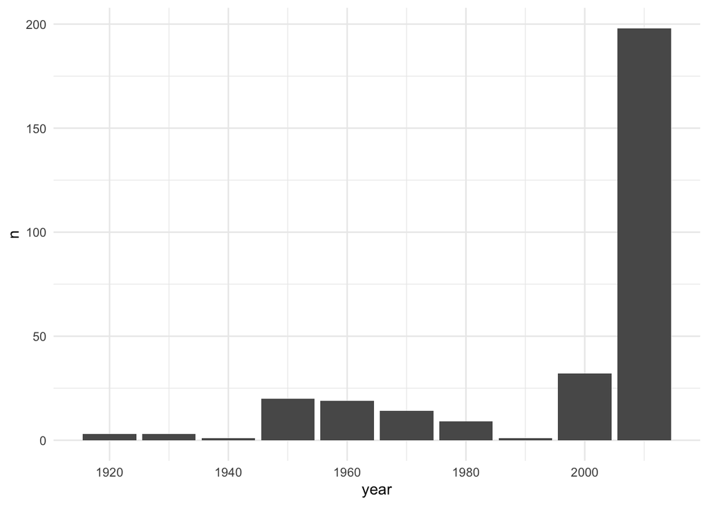

```r
us |>
  group_by(city) |>
  arrange(desc(population)) |>
  slice(1) |>
  ungroup() |>
  group_by(year) |>
  summarize(n = n()) |>
  ggplot(aes(year, n)) +
  geom_col()
```

Try to identify the three different clusters of peak city sizes. **Note**: There is a small cluster in 1920 corresponding the mill cities in the Northeastern U.S., a cluster in the 1950s and 1960s of cities that decreased in size due to white flight and gerrymandering, and (the large cluster) of cities that are larger today that they have ever been.

To finish, in the code below take the `us` dataset and use the filter function to select only cities with a longitude greater than -125. Select the row corresponding to each cities largest year of population (as we did in one of the previous questions) and produce a scatterplot with longitude on the x-axis and latitude on the y-axis. Color the points according to the year that the city attained its largest population and include a color-blind friendly color scale. Finally, sort the data in descending order of year before plotting.

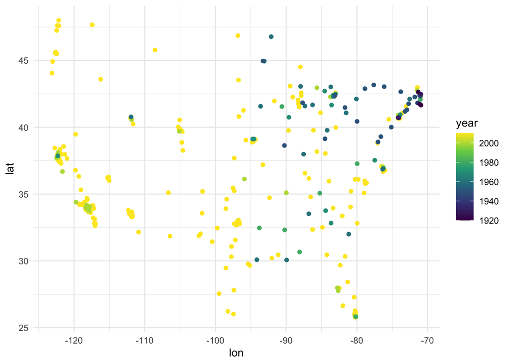

```r
us |>
  group_by(city) |>
  arrange(desc(population)) |>
  slice(1) |>
  filter(lon > -125) |>
  ungroup() |>
  arrange(desc(year)) |> # puts the earliest years on top
  ggplot(aes(lon, lat)) +
  geom_point(aes(color = year)) +
  scale_color_viridis_c()
```

Try to match up the clusters of years with locations on the map.